# How Do Various Factors Influence Urban Road Safety in Barcelona?

Angelo Di Gianvito, Rui Maciel, Viktoriia Yuzkiv

2024-03-28

# 1. Introduction

Living in Barcelona, a city vibrant with life and movement, we are constantly navigating its streets, whether on foot, by bike, or in a vehicle. However, amidst its beauty and energy, Barcelona, like any other urban center, grapples with the challenge of road safety. The occurrence of car accidents, ranging from minor collisions to tragic fatalities, underscores the importance of understanding the dynamics of road incidents within the city.

As residents of Barcelona, our team recognizes the necessity of exploring the spatial patterns and factors influencing car accidents. By delving into the distribution of accidents across different districts, examining the severity of injuries and fatalities, we aim to unearth insights that can inform not only our personal vigilance but also contribute to broader discussions on urban safety measures.

Using a geospatial data and approach, our research proposal has the goal of giving an overview of the accidents paradigm of Barcelona and to foster further investigation through geospatial tools. We utilize data provided by the Ayuntamiento de Barcelona, which geospatially pinpoints the exact locations of accidents.

This data has enabled us to pinpoint compelling areas for future research, such as pinpointing Eixample as Barcelona’s primary accident hotspot and investigating the potential non-linear relationship between the number of accidents and the resultant casualties. Through the analysis of urban geospatial characteristics, such as the closeness to crosswalks and the intensity of traffic patterns, we discovered a notable correlation indicating that accidents are more likely to happen near crosswalks and in zones experiencing higher traffic flow. Additionally, our research proposal concludes with an investigation into whether these factors also influence the number of victims involved.

Our goal is to enhance the existing literature by identifying environmental and infrastructural causes of accidents in Barcelona, moving beyond the scope of human behavior.

# 2. State of Art

The integration of geospatial features into the study and prediction of road traffic accidents (RTAs) has marked a significant evolution in the field of urban planning and public safety. Through the examination of various research findings, it becomes evident that geospatial data is pivotal in uncovering the relations between urban environments and accident occurrences.

The core of these studies lies in their innovative use of Geographic Information Systems (GIS) and spatial analysis techniques to map and analyze the distribution and determinants of RTAs across different urban settings. For instance, detailed spatial analyses conducted in cities like Barcelona, as discussed by Chaudhuri et al. (2023) , and Lisbon, analyzed by Mesquitela et al. (2022) , leveraged geospatial data to identify high-risk road segments and accident clusters. These studies effectively demonstrate how geospatial data can be utilized to provide detailed insights into the spatial patterns of traffic accidents, enabling the development of targeted safety measures.

Moreover, the spatial-temporal variability highlighted in the research, such as in the studies from Belgrade by Lović Obradović et al. (2022) and Bursa by Haybat et al. (2022) , emphasizes the dynamic nature of RTA risk factors. Geospatial features, when analyzed over time, reveal how accident hotspots evolve and how factors such as time of day, seasonality, and specific urban configurations contribute to the risk of accidents. These findings are crucial for implementing dynamic and responsive urban safety strategies that can adapt to changing urban landscapes and mobility patterns.

Additionally, the application of geospatial data extends beyond traditional analysis, as demonstrated by the use of machine learning models to predict RTA risks. Shi et al. (2021) incorporated geospatial features into machine learning models, offering a granular geospatial view of accident probabilities across urban road networks. This approach represents a forward leap in predictive analytics, providing a tool for preemptive safety planning and risk assessment at the road segment level.

Building on this foundation, this literature review has underscored the indispensable role of geospatial data in understanding the dynamics between urban features and road traffic accidents, particularly in pinpointing accident hotspots. Inspired by the comprehensive analysis presented in the Barcelona study (Chaudhuri et al. (2023)), we aim to delve deeper into the influence of geospatial characteristics on accident causation. This project not only seeks to identify prevailing patterns and contributing factors but also to uncover new insights that could stimulate further research. By extending the application of geospatial analysis, we hope to contribute to the body of knowledge with nuanced findings that could guide the development of more effective urban safety measures and traffic management strategies.

# 3. Data

Our project utilizes data sourced from the “Open Data BCN” platform, provided by the Ayuntamiento de Barcelona. The datasets incorporated into our research include:

**Traffic Accident Data for 2023**: Accessible at https://opendata-ajuntament.barcelona.cat/data/en/dataset/accidents_causa_conductor_gu_bcn, this dataset comprises 7,724 records, detailing each traffic incident comprehensively. A critical aspect of this dataset is the precise accident locations, pivotal for our analysis—from calculating distances to integrating with other spatial data. Additionally, it offers detailed categorizations of injuries and fatalities, serving as the dependent variables in our study.

**Barcelona District Boundaries**: Available at https://opendata-ajuntament.barcelona.cat/data/en/dataset/20170706-districtes-barris/resource/576bc645-9481-4bc4-b8bf-f5972c20df3f, this resource delineates the boundaries of Barcelona’s districts, integral to spatially orienting our analysis within the city’s administrative divisions.

**Inventory of Crosswalks in Barcelona**: Retrieved from https://opendata-ajuntament.barcelona.cat/data/ca/dataset/infraestructures-inventari-pas-vianants, this dataset catalogs every crosswalk in Barcelona, emphasizing their exact locations. The comprehensive detailing of crosswalks supports our exploration of pedestrian safety and mobility patterns.

**Traffic Flow Data**: Sourced from https://opendata-ajuntament.barcelona.cat/data/en/dataset/trams, it provides traffic volume information across various city streets, captured in 15-minute intervals. This temporal granularity allows for a dynamic understanding of traffic flow, enriching our analysis with temporal traffic patterns.

Leveraging these differents datasets, we aim to not only apply the methodologies and tools explored in our coursework but also to delve into the application of geospatial analysis in the context of traffic accidents. This approach will not only enrich the understanding of urban safety dynamics but also pave the way for future research, showcasing the potential of geospatial technologies in addressing complex urban challenges. Let’s, then, explore the primary dataset that will form the basis of our analysis.

```r
# Load the data
districts_data <- read.csv('BarcelonaCiutat_Districtes.csv')
accidents_data <- read.csv('2023_accidents_gu_bcn (1).csv')

# Convert districts and accidents data to sf objects
districts_sf <- st_as_sf(districts_data, wkt = "geometria_wgs84", crs = 4326)
accidents_sf <- st_as_sf(accidents_data, coords = c("Longitud_WGS84", "Latitud_WGS84"), crs = 4326)

# Shape of the accidents df
dim(accidents_data)
```

```
## [1] 7724   25
```

In 2023, there were 7724 traffic accidents in the city.

```r
# Remove observations with missing data (filter out -1 values from Codi_districte)
accidents_data <- accidents_data %>%
  filter(Codi_districte != -1)

head(accidents_data)
```

```
##   Numero_expedient Codi_districte  Nom_districte Codi_barri
## 1  2023S000001                  3 Sants-Montjuïc         18
## 2  2023S000002                  7 Horta-Guinardó         33
## 3  2023S000003                  1   Ciutat Vella          1
## 4  2023S000005                  6         Gràcia         31
## 5  2023S000006                  6         Gràcia         31
## 6  2023S000007                  3 Sants-Montjuïc         12
##                    Nom_barri Codi_carrer
## 1                      Sants       30602
## 2           el Baix Guinardó      109203
## 3                   el Raval       67307
## 4          la Vila de Gràcia      282401
## 5          la Vila de Gràcia      206403
## 6 la Marina del Prat Vermell         180
##                                           Nom_carrer Num_postal.
```

[output cut: 41 more lines]

The main dataset includes detailed information on car accidents, such as precise coordinates and metadata like geospatial characteristics (district, neighborhood, street) and time characteristics (month, day, hour). It also provides data on the number of victims categorized by severity (fatalities, serious injuries, minor injuries). This allows us to analyze the spatial and temporal distribution of accidents and understand the impact on human casualties.

# 4. Understanding Accidents and Number of Victims relation

## 4.1. Understanding the accident landscape

In this section, we delve into the data regarding the frequency and distribution of car accidents in Barcelona. Utilizing the heatmap and district-level map, we aim to visualize the concentration of incidents across the city, providing an overview of the accident landscape. This analysis offers valuable insights into how accidents are distributed across the city’s different areas, shedding light on potential hotspots and areas of concern.

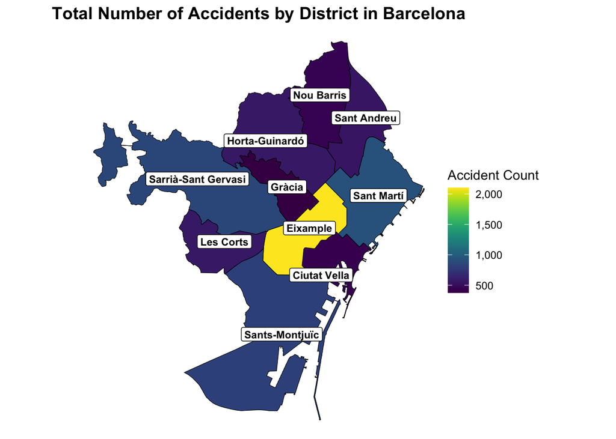

```r
# Aggregate the number of accidents by district
accidents_agg <- accidents_data %>%
  group_by(Codi_districte) %>%
  summarize(total_accidents = n())

# Merge the aggregated data with districts_sf
districts_sf_joined <- left_join(districts_sf, accidents_agg, by = c("codi_districte" = "Codi_districte"))

# Plot the data
ggplot() +
  geom_sf(data = districts_sf_joined, aes(fill = total_accidents), color = 'black') +  # Plot districts
  geom_sf_label(data = districts_sf_joined, aes(label = nom_districte), size = 3, label.padding = unit(0.25, "lines"), fontface = "bold") + # Add district names
  scale_fill_viridis(option = "viridis", discrete=FALSE, name = "Accident Count", labels = scales::comma) +
  labs(title = "Total Number of Accidents by District in Barcelona") +
  theme_void() +
  theme(plot.title = element_text(size = 14, face = "bold", hjust = 0.5))
```

The map denotes Eixample as the epicenter of road traffic accidents within Barcelona for the year 2023, with accident occurrences markedly higher than in neighboring districts such as Sant Martí, Sarrià-Sant Gervasi, and Sants-Montjuïc, which report about 2.3 to 2.6 times fewer incidents. This concentration of accidents in Eixample could likely be a result of it being the center of critical transit routes, including the major sections of Avenida Diagonal and Gran Via de les Corts Catalanes.

Conversely, districts like Gràcia and Ciutat Vella register fewer accidents, which might be attributed to their narrower streets that naturally temper traffic flow and, by extension, potential accidents. The restricted roadways in these areas discourage heavy vehicle circulation, contributing to a lower accident rate.

To validate these observations and refine our understanding of the underlying causes, a thorough analysis of the traffic data and street layouts in these districts will be essential. Additionally, plotting a heatmap instead of aggregating by district could offer further insights into the most frequent areas of accidents.

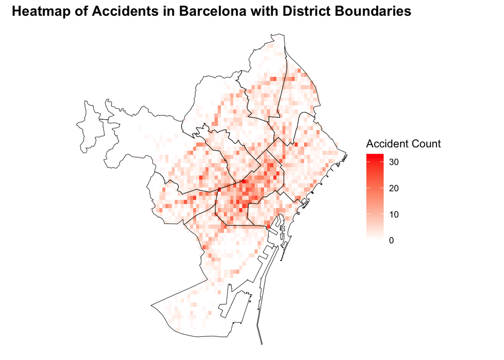

```r
# Define the extent based on the accidents data
ext <- st_bbox(accidents_sf)
r_extent <- raster::extent(ext$xmin, ext$xmax, ext$ymin, ext$ymax)

# Define resolution
res <- 0.002 # Adjust resolution based on the dataset

# Calculate the number of rows and columns based on the resolution
num_rows <- ceiling((ext$ymax - ext$ymin) / res)
num_cols <- ceiling((ext$xmax - ext$xmin) / res)

# Create an empty raster with defined extent and resolution
r <- raster::raster(nrows=num_rows, ncols=num_cols, xmn=ext$xmin, xmx=ext$xmax, ymn=ext$ymin, ymx=ext$ymax)

# Set the resolution of the raster
res(r) <- c(res, res)

# Rasterize the accidents data
accidents_raster <- rasterize(x=accidents_sf, y=r, field=1, fun='count', background=0)

# Convert the raster to a dataframe
accidents_df <- as.data.frame(accidents_raster, xy=TRUE)

# Replace NA with 0 if any NAs are present
if(any(is.na(accidents_df$value))) {
  accidents_df$value[is.na(accidents_df$value)] <- 0
}

# Proceed to plot the heatmap
ggplot() +
  geom_tile(data = accidents_df, aes(x = x, y = y, fill = layer)) +  # Heatmap of accidents
  geom_sf(data = districts_sf, fill = NA, color = "black", size = 0.2) +  # Boundaries of districts
  scale_fill_gradient(low = "white", high = "red", name = "Accident Count") +
  coord_sf(datum = NA) +
  labs(title = "Heatmap of Accidents in Barcelona with District Boundaries") +
  theme_void() +
  theme(plot.title = element_text(size = 14, face = "bold", hjust = 0.5))
```

The heatmap displays accident data for Barcelona, with the district boundaries outlined. The visual pattern of the heatmap suggests that accidents are not distributed evenly across the city but are rather concentrated along certain roadways, which become evident even without explicitly plotting them. For instance, major routes like Avenida Diagonal and Gran Via de les Corts Catalanes show up prominently due to the high number of accidents, highlighting them as high-risk areas.

Furthermore, the central area of the city, which is likely to correspond with dense traffic and complex intersections, appears as a hotspot with a particularly high frequency of accidents. The heatmap also implies that certain districts have a higher propensity for accidents, which could correlate with factors such as traffic volume, road design, or the presence of commercial zones.

Areas like Eixample stand out with a substantial accumulation of accidents again. This could be attributed to its grid layout, which, while designed to ease traffic flow, may also lead to higher vehicle speeds and increased interactions at intersections, contributing to the higher accident rate observed. The granularity of the data in the heatmap provides an opportunity to delve deeper into specific urban planning and traffic management strategies to enhance road safety in these highlighted areas.

## 4.2. Exploring accident severity

Building on our knowledge of accident hotspots, we will next turn our attention to analyzing the most significant consequence of these incidents: the impact on human life and well-being. Where accidents happen may not be necessarily where the human cost is higher. To understand that, we will examine the following key indicators:

- Fatalities Count (Numero_morts) – representing the toll of lives lost,
- Minor Injuries Count (Numero_lesionats_lleus) – indicating the frequency of less severe health impacts,
- Serious Injuries Count (Numero_lesionats_greus) – reflecting more critical health consequences, and
- Total Victims Count (Numero_victimes) – summarizing the overall human toll. By analyzing these metrics, we can identify critical areas that require urgent attention to enhance road safety and protect life.

```r
# Print the summary (total count) for each column
total_sum <- c(
  Numero_morts = sum(accidents_data$Numero_morts),
  Numero_lesionats_lleus = sum(accidents_data$Numero_lesionats_lleus),
  Numero_lesionats_greus = sum(accidents_data$Numero_lesionats_greus),
  Numero_victimes = sum(accidents_data$Numero_victimes)
)

# Print the total sum for each column
print(total_sum)
```

```
##           Numero_morts Numero_lesionats_lleus Numero_lesionats_greus
##                     21                   8460                    227
##        Numero_victimes
##                   8708
```

In 2023, a total of 8,708 individuals were involved in car accidents. Among them, 21 lost their lives, while 227 sustained serious injuries. The majority of incidents resulted in minor injuries, with 8,460 individuals affected.

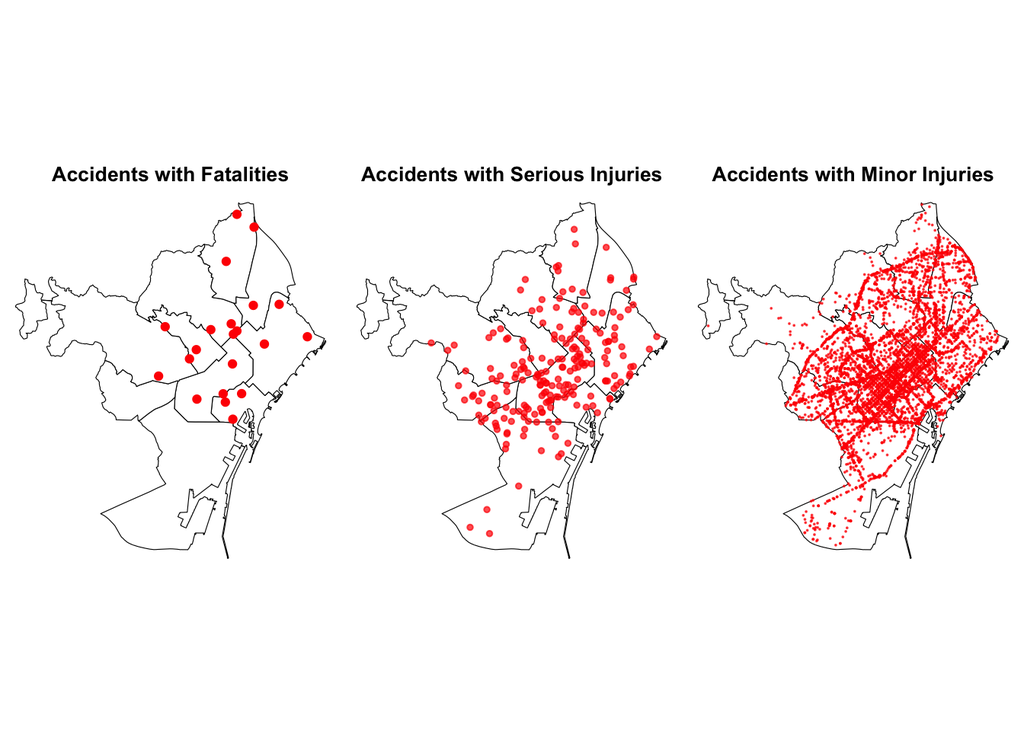

```r
# Filter the dataset (fatalities)
accidents_with_fatalities <- accidents_sf[accidents_sf$Numero_morts > 0, ]

# Create a plot using ggplot2
plot_fatalities <- ggplot() +
  geom_sf(data = districts_sf, fill = 'white', color = 'black') +  # Plot districts
  geom_sf(data = accidents_with_fatalities, color = 'red', size = 1.5, alpha = 1) + # Plot accidents
  theme_void() +
  labs(title = "Accidents with Fatalities") +
  theme(plot.title = element_text(size = 10, face = "bold", hjust = 0.5),
        plot.caption = element_text(size = 8, hjust = 0.5))


# Create a plot using ggplot2
accidents_with_serious_injuries <- accidents_sf[accidents_sf$Numero_lesionats_greus > 0, ]

# Plot the data using ggplot2
plot_serious_injuries <- ggplot() +
  geom_sf(data = districts_sf, fill = 'white', color = 'black') +  # Plot districts
  geom_sf(data = accidents_with_serious_injuries, color = 'red', size = 1, alpha = 0.7) + # Plot accidents
  theme_void() +
  labs(title = "Accidents with Serious Injuries") +
  theme(plot.title = element_text(size = 10, face = "bold", hjust = 0.5))

# Create a plot using ggplot2
accidents_with_minor_injuries <- accidents_sf[accidents_sf$Numero_lesionats_lleus > 0, ]

# Plot the data using ggplot2
plot_minor_injuries <- ggplot() +
  geom_sf(data = districts_sf, fill = 'white', color = 'black') +  # Plot districts
  geom_sf(data = accidents_with_minor_injuries, color = 'red', size = 0.01, alpha = 0.7) + # Plot accidents
  theme_void() +
  labs(title = "Accidents with Minor Injuries") +
  theme(plot.title = element_text(size = 10, face = "bold", hjust = 0.5))

# Arrange plots side by side
grid.arrange(plot_fatalities, plot_serious_injuries, plot_minor_injuries, ncol = 3)
```

While Eixample leads in accident frequency (and even in accidents with serious injuries), it would expect that most of the fatalities would also happen there. Eixample’s dense traffic could lead to numerous accidents, yet with outcomes less fatal due to lower speed limits or urban safety designs. This disparity between injury levels and fatalities across accidents suggests influential factors such as vehicle safety features and/or timely medical responses are at play.

However, evaluating the sheer number of accidents per district isn’t as revealing as assessing the proportion of injuries per accident. This approach would more accurately identify and differentiate the districts on the spectrum from high safety to high risk, providing critical data for targeted, area-specific traffic safety strategies.

```r
library(purrr)


# Assuming accidents_data and districts_sf are pre-loaded datasets

# Calculate the total number of accidents by district
accidents_by_district <- accidents_data %>%
  group_by(Nom_districte, Codi_districte) %>%
  summarize(total_accidents = n())
```

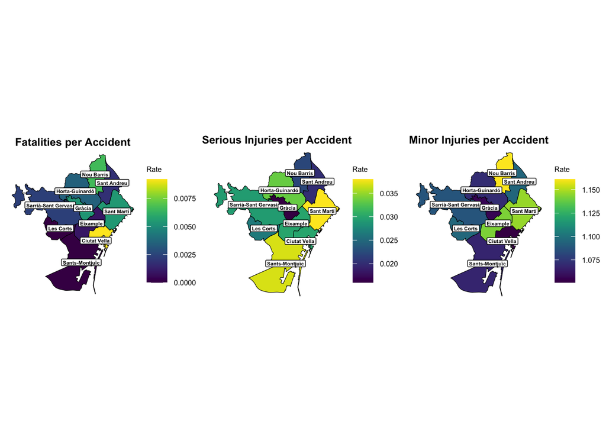

```r
# Calculate the total number of serious injuries by district
serious_injuries_by_district <- accidents_data %>%
  group_by(Nom_districte) %>%
  summarize(total_serious_injuries = sum(Numero_lesionats_greus, na.rm = TRUE))

# Calculate the total number of minor injuries by district
minor_injuries_by_district <- accidents_data %>%
  group_by(Nom_districte) %>%
  summarize(total_minor_injuries = sum(Numero_lesionats_lleus, na.rm = TRUE))

# Calculate the total number of fatalities by district
fatalities_by_district <- accidents_data %>%
  group_by(Nom_districte) %>%
  summarize(total_fatalities = sum(Numero_morts, na.rm = TRUE))

# Merge datasets
accidents_summary_by_district <- reduce(list(accidents_by_district, serious_injuries_by_district, minor_injuries_by_district, fatalities_by_district), full_join, by = "Nom_districte")

# Calculate rates
accidents_summary_by_district <- accidents_summary_by_district %>%
  mutate(
    minor_injuries_per_accident = total_minor_injuries / total_accidents,
    serious_injuries_per_accident = total_serious_injuries / total_accidents,
    fatalities_per_accident = total_fatalities / total_accidents
  )

# Merge with spatial data
districts_sf_joined <- left_join(districts_sf, accidents_summary_by_district, by = c("nom_districte" = "Nom_districte"))

# Set common theme for all plots
custom_theme <- function() {
  theme_void() +
  theme(
    legend.position = "right",
    legend.direction = "vertical",
    legend.title = element_text(size = 6),
    legend.text = element_text(size = 6),
    plot.title = element_text(size = 9, face = "bold", hjust = 0.5, vjust = 1),
    plot.margin = margin(5, 5, 5, 5)  # Adjust the margin numbers (top, right, bottom, left) as needed
  )
}


# Creating the plot for Minor Injuries
plot_minor_injuries <- ggplot(data = districts_sf_joined, aes(fill = minor_injuries_per_accident)) +
  geom_sf(color = 'black') +
  geom_sf_label(aes(label = nom_districte), fill = "white", size = 1.5, label.padding = unit(0.25, "lines"), fontface = "bold") +
  scale_fill_viridis(name = "Rate", option = "viridis", discrete = FALSE, labels = scales::comma) +
  labs(title = "Minor Injuries per Accident") +
  custom_theme()

# Creating the plot for Serious Injuries
plot_serious_injuries <- ggplot(data = districts_sf_joined, aes(fill = serious_injuries_per_accident)) +
  geom_sf(color = 'black') +
  geom_sf_label(aes(label = nom_districte), fill = "white",size = 1.5, label.padding = unit(0.25, "lines"), fontface = "bold") +
  scale_fill_viridis(name = "Rate",option = "viridis", discrete = FALSE, labels = scales::comma) +
  labs(title = "Serious Injuries per Accident") +
  custom_theme()

# Creating the plot for Fatalities
plot_fatalities <- ggplot(data = districts_sf_joined, aes(fill = fatalities_per_accident)) +
  geom_sf(color = 'black') +
  geom_sf_label(aes(label = nom_districte), fill = "white",size = 1.5, label.padding = unit(0.25, "lines"), fontface = "bold") +
  scale_fill_viridis(name = "Rate", option = "viridis", discrete = FALSE, labels = scales::comma) +
  labs(title = "Fatalities per Accident") +
  custom_theme()


# Use the gridExtra package to arrange the plots
grid.arrange(plot_fatalities, plot_serious_injuries, plot_minor_injuries, ncol = 3)
```

The above maps provide the impact of traffic accidents across Barcelona’s districts. The maps suggest a not linear relationship between the frequency of accidents and the severity of their consequences.

Observing Nou Barris, the data paints a paradoxical picture: despite registering a lower number of accidents, the district has a notably higher rate of injuries per accident. This stark contrast implies that while accidents are infrequent, they may tend to be of a severe nature when they do occur.

Sant Marti tells a similar story, with fewer accidents overall yet a high rate of injuries per incident. The high injury rate despite lower accident numbers may point to specific risk factors in Sant Marti that increase the likelihood of more severe outcomes when accidents take place.

What becomes evident from these visualizations is that the frequency of accidents does not directly correlate with their severity. A district like Eixample can have numerous accidents with less severe outcomes, whereas districts like Nou Barris and Sant Marti, with fewer accidents, can still experience a greater impact per accident. This suggests that district-specific factors—possibly including road design, traffic flow, and local enforcement of safety measures significantly influence the nature and consequences of traffic incidents.

# 5. Identifying contributing factors

This section focuses on potential factors contributing to the rise in the number of accidents and victims in Barcelona. We investigate seasonal variations in accident rates, examine the proximity of accidents to crosswalks, and assess the influence of traffic levels on incident occurrence.

## 5.1. Unveiling seasonal trends

Delving into temporal patterns, we explore how the occurrence of accidents fluctuates throughout the day and across different months.

### 5.1.1. Time of the day

```r
# Number of accidents by hour
accidents_data %>%
  group_by(Hora_dia) %>%
  summarize(total_accidents = n()) %>%
  arrange(desc(total_accidents))
```

```
## # A tibble: 24 × 2
##    Hora_dia total_accidents
##       <int>           <int>
##  1       14             557
##  2       17             533
##  3       18             522
##  4       19             519
##  5       13             508
##  6       16             500
##  7       12             463
##  8       15             457
##  9       20             436
## 10        8             415
## # ℹ 14 more rows
```

```r
# Aggregate the number of accidents by district and hour of the day
accidents_agg <- accidents_data %>%
  group_by(Codi_districte, Hora_dia) %>%
  summarize(total_accidents = n())
```

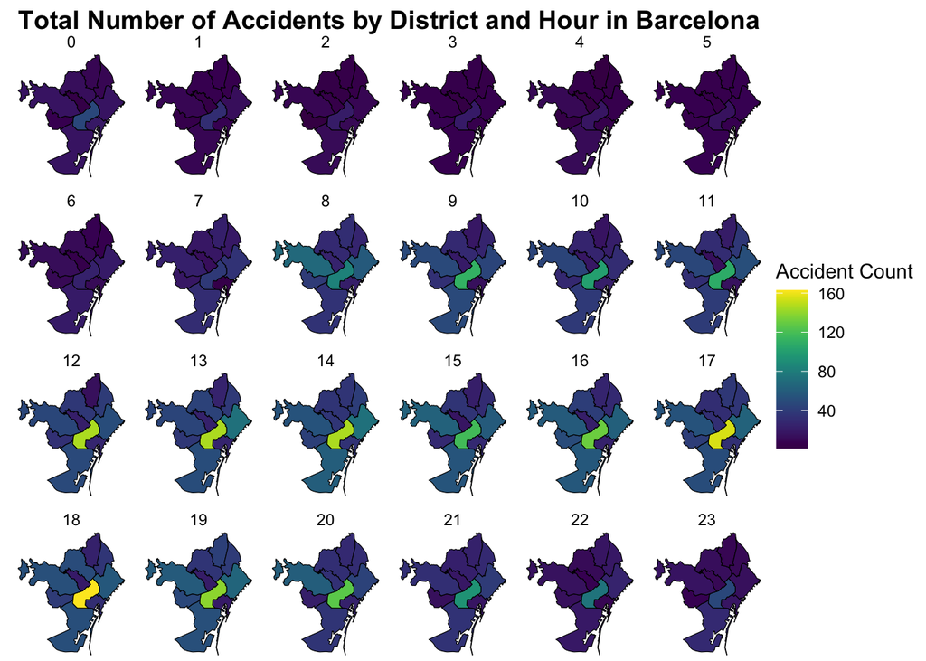

```r
# Merge the aggregated data with districts_sf
districts_sf_joined <- left_join(districts_sf, accidents_agg, by = c("codi_districte" = "Codi_districte"))

# Plot the data
ggplot() +
  geom_sf(data = districts_sf_joined, aes(fill = total_accidents), color = 'black') +  # Plot districts
  scale_fill_viridis(option = "viridis", discrete=FALSE, name = "Accident Count", labels = scales::comma) +
  labs(title = "Total Number of Accidents by District and Hour in Barcelona") +
  theme_void() +
  theme(plot.title = element_text(size = 14, face = "bold", hjust = 0.5)) +
  facet_wrap(~Hora_dia, ncol = 6) # Facet plot by hour of the day
```

```r
# Aggregate the number of accidents by district name and hour of the day
accidents_agg_names <- accidents_data %>%
  group_by(Nom_districte, Hora_dia) %>%
  summarize(total_accidents = n())
```

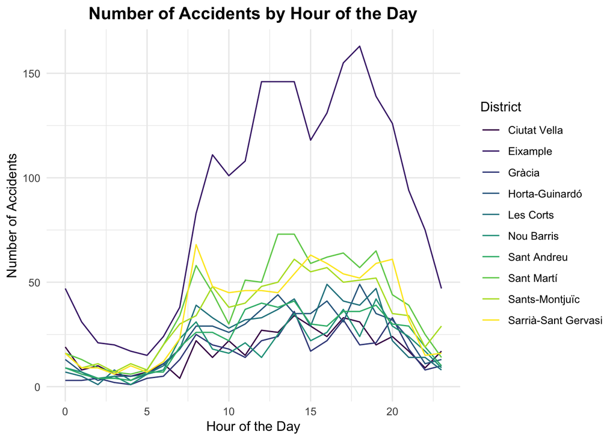

```r
# Plot the line plot for number of accidents by hour
ggplot(accidents_agg_names, aes(x = Hora_dia, y = total_accidents, color = factor(Nom_districte))) +
  geom_line() +
  scale_color_viridis_d() + # Apply viridis color scheme
  labs(title = "Number of Accidents by Hour of the Day",
       x = "Hour of the Day",
       y = "Number of Accidents",
       color = "District") +
  theme_minimal() +
  theme(plot.title = element_text(size = 14, face = "bold", hjust = 0.5))
```

As expected, the number of accidents decreases during the night. Notably, in Eixample, the number of accidents during the night is much lower than during the day and is comparable to the levels in other districts. Interestingly, in Eixample, the number of accidents decreases at 15:00 and then rises again, reaching its peak at 18:00. The highest number of accidents in 2023 occurred at 14:00. It turns out that, generally, there are fewer accidents at 15:00 compared to the hours immediately before and after it.

### 5.1.2. Month

```r
# Number of accidents by month
accidents_data %>%
  group_by(Mes_any) %>%
  summarize(total_accidents = n()) %>%
  arrange(desc(total_accidents))
```

```
## # A tibble: 12 × 2
##    Mes_any total_accidents
##      <int>           <int>
##  1       6             702
##  2       5             698
##  3       7             681
##  4      11             673
##  5       4             670
##  6      10             669
##  7       3             663
##  8       1             602
##  9       9             582
## 10      12             580
## 11       2             579
## 12       8             535
```

```r
# Aggregate the number of accidents by district and hour of the day
accidents_agg_month <- accidents_data %>%
  group_by(Codi_districte, Mes_any) %>%
  summarize(total_accidents = n())
```

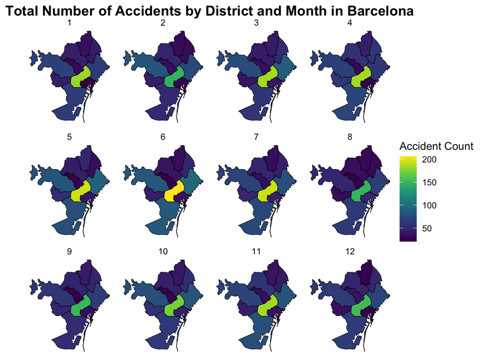

```r
# Merge the aggregated data with districts_sf
districts_sf_joined_month <- left_join(districts_sf, accidents_agg_month, by = c("codi_districte" = "Codi_districte"))

# Plot the data
ggplot() +
  geom_sf(data = districts_sf_joined_month, aes(fill = total_accidents), color = 'black') +  # Plot districts
  scale_fill_viridis(option = "viridis", discrete=FALSE, name = "Accident Count", labels = scales::comma) +
  labs(title = "Total Number of Accidents by District and Month in Barcelona") +
  theme_void() +
  theme(plot.title = element_text(size = 14, face = "bold", hjust = 0.5)) +
  facet_wrap(~Mes_any, ncol = 4) # Facet plot by hour of the day
```

```r
# Aggregate the number of accidents by district name and hour of the day
accidents_agg_names_month <- accidents_data %>%
  group_by(Nom_districte, Mes_any) %>%
  summarize(total_accidents = n())
```

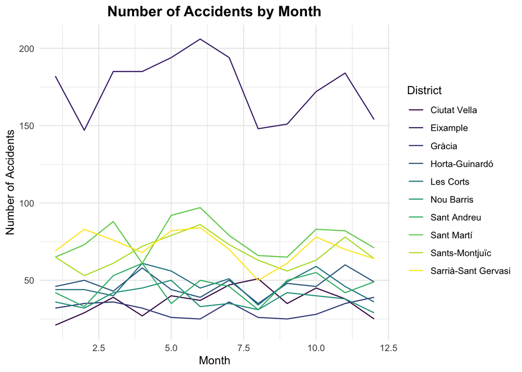

```r
# Plot the line plot for number of accidents by hour
ggplot(accidents_agg_names_month, aes(x = Mes_any, y = total_accidents, color = factor(Nom_districte))) +
  geom_line() +
  scale_color_viridis_d() + # Apply viridis color scheme
  labs(title = "Number of Accidents by Month",
       x = "Month",
       y = "Number of Accidents",
       color = "District") +
  theme_minimal() +
  theme(plot.title = element_text(size = 14, face = "bold", hjust = 0.5))
```

An analysis of the monthly distribution of traffic incidents across various districts revails that certain districts, notably the Eixample district, were markedly more prone to incident amplification.

These findings emphasize the importance of targeted interventions to address unique risk factors in different parts of the city, ultimately enhancing overall road safety measures.

## 5.2. Proximity to crosswalks

By analyzing the distance between accident locations and nearby crosswalks, we aim to uncover any correlations between accident frequency and the presence of pedestrian infrastructure.

```r
# Load crosswalks data
crosswalks_data <- read.csv('Infraestructures_Inventari_Pas_Vianants.csv')

# Filter out records where Data_Alta is greater than January 1, 2024 and Data_Baixa is smaller than January 1, 2023 so that we keep the crosswalks that were active in 2023
crosswalks_data <- crosswalks_data %>%
  filter(Data_Alta < as.Date("2024-01-01")) %>%
  filter(Data_Baixa == "" | Data_Baixa >= as.Date("2023-01-01"))

crosswalks_sf <- st_as_sf(crosswalks_data, coords = c("Longitud", "Latitud"), crs = 4326)

# Calculate distances between each accident point and all crosswalk points
distances <- st_distance(accidents_sf, crosswalks_sf)

# Find the minimum distance for each accident point
min_distances <- apply(distances, 1, min)

# Add the minimum distances to the accidents_sf dataset
accidents_sf$closest_crosswalk_distance <- min_distances

# Remove outliers from the closest_crosswalk_distance column:
# Calculate the first and third quartiles
q1 <- quantile(accidents_sf$closest_crosswalk_distance, 0.25)
q3 <- quantile(accidents_sf$closest_crosswalk_distance, 0.75)

# Calculate the interquartile range (IQR)
iqr <- q3 - q1

# Define the lower and upper bounds for outliers
lower_bound <- q1 - 1.5 * iqr
upper_bound <- q3 + 1.5 * iqr

# Remove outliers
accidents_sf_trimmed <- subset(accidents_sf, closest_crosswalk_distance >= lower_bound & closest_crosswalk_distance <= upper_bound)
```

Let’s check for a potential relationship between the number of accidents and the average closest distance to crosswalks at the neighborhood level. We are utilizing neighborhoods instead of districts here for a lower granularity level, thereby yielding more precise results.

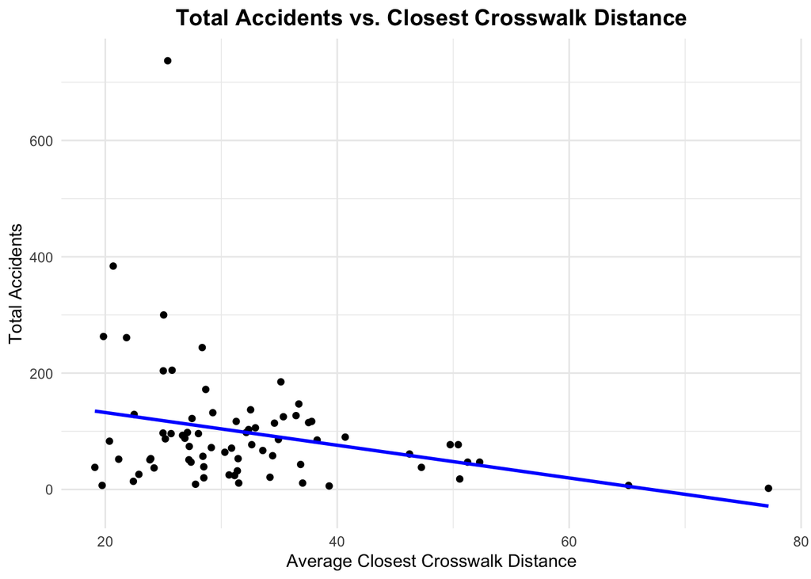

```r
# Group data by Codi_barri and calculate count of accidents and average closest_crosswalk_distance
grouped_data <- accidents_sf_trimmed %>%
  group_by(Codi_barri) %>%
  summarize(total_accidents = n(),
            avg_distance = mean(closest_crosswalk_distance, na.rm = TRUE))

# Run linear regression
linear_model <- lm(total_accidents ~ avg_distance, data = grouped_data)

# Add regression line to the scatter plot
scatter_with_regression <- ggplot(grouped_data, aes(x = avg_distance, y = total_accidents)) +
  geom_point() +
  geom_smooth(method = "lm", se = FALSE, color = "blue") +  # Add linear regression line
  labs(title = "Total Accidents vs. Closest Crosswalk Distance",
       x = "Average Closest Crosswalk Distance",
       y = "Total Accidents") +
  theme_minimal() +
  theme(plot.title = element_text(size = 14, face = "bold", hjust = 0.5))

# Print the scatter plot with regression line
print(scatter_with_regression)
```

```r
# Print summary of linear regression
summary(linear_model)
```

```
##
## Call:
## lm(formula = total_accidents ~ avg_distance, data = grouped_data)
##
## Residuals:
##     Min      1Q  Median      3Q     Max
## -126.02  -63.59  -18.67   27.74  619.88
##
## Coefficients:
##              Estimate Std. Error t value Pr(>|t|)
## (Intercept)   188.492     39.063   4.825 7.59e-06 ***
## avg_distance   -2.812      1.153  -2.439   0.0172 *
## ---
## Signif. codes:  0 '***' 0.001 '**' 0.01 '*' 0.05 '.' 0.1 ' ' 1
##
## Residual standard error: 101.4 on 72 degrees of freedom
## Multiple R-squared:  0.07631,    Adjusted R-squared:  0.06348
## F-statistic: 5.948 on 1 and 72 DF,  p-value: 0.0172
```

Based on the results of the linear regression above, the coefficient for avg_distance is negative (-2.812), indicating that, on average, as the average distance to the closest crosswalk increases, the number of accidents in the neighborhood decreases (significant at the 5% significance level). This suggests that, according to the model, areas closer crosswalks tend to have more car accidents. However, it’s essential to interpret this result with caution and remember that factors such as road conditions, traffic flow, visibility, and driver behavior may also play significant roles in accident occurrence.

## 5.3. Impact of traffic levels

We investigate the relationship between traffic volumes and the likelihood of accidents, examining how congestion levels may contribute to road safety challenges. Due to the large size of the traffic data and computational constraints, we utilize traffic data for January 2023 only.

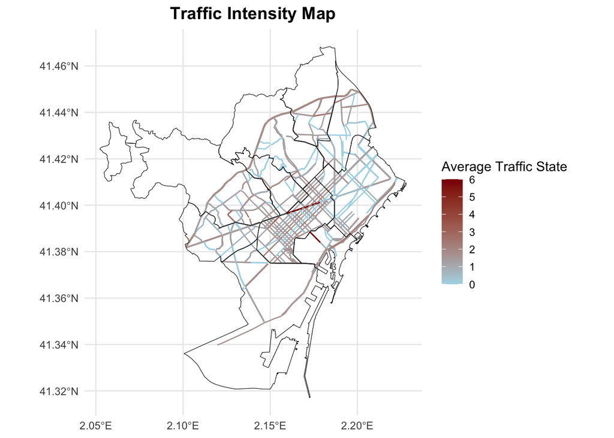

```r
#Load roads map as it will be our bas
streets_data <- read.csv('transit_relacio_trams.csv')

# Parse 'coordenades' into a list of numeric vectors
streets_data$coordenades_parsed <- lapply(streets_data$Coordenades, function(coord_str) {
  # Split the string into individual numbers
  coord_parts <- unlist(strsplit(coord_str, ","))
  # Convert the character vector to a numeric matrix (2 columns for longitude and latitude)
  matrix(as.numeric(coord_parts), ncol = 2, byrow = TRUE)
})

# Create LineString geometries
streets_data$geometry <- lapply(streets_data$coordenades_parsed, function(coords) {
  st_linestring(coords)
})

streets_data_sf <- st_sf(streets_data, geometry = st_sfc(streets_data$geometry, crs = 4326))

# Perform spatial intersection to retain only streets within the city limits
streets_within_city_limits <- st_intersection(streets_data_sf, st_union(districts_sf))
# Load the traffic dataset into a dataframe
traffic_flow <- read_csv("/Users/ruimaciel/Desktop/Barcelona/Geospatial/Traffic/2023_01_Gener_TRAMS_TRAMS.csv", show_col_types = FALSE)

# Convert the data column to character for datetime parsing
traffic_flow$data <- as.character(traffic_flow$data)

# Attempt to parse each date-time, substituting NA for failures
traffic_flow <- traffic_flow %>%
  mutate(data_parsed = case_when(
    !is.na(data) ~ ymd_hms(data, quiet = TRUE),
    TRUE ~ as.POSIXct(NA)
  ))

# Plot average traffic state in January 2023
traffic_january <- traffic_flow %>%
  group_by(idTram) %>%
  summarise(average_state = mean(estatActual, na.rm = TRUE), .groups = 'drop')

# Merge the traffic data with the street segments data
streets_data_traffic <- merge(streets_within_city_limits, traffic_january, by.x = "Tram", by.y = "idTram")

ggplot(data = streets_data_traffic) +
  geom_sf(aes(color = average_state)) +
  scale_color_gradient(low = "lightblue", high = "darkred") + # Custom color scale
  geom_sf(data = districts_sf, color = 'black', fill = NA, alpha=0.1) +  # Plot districts
  theme_minimal() +
  labs(title = "Traffic Intensity Map",
       color = "Average Traffic State") +
  theme(plot.title = element_text(size = 14, face = "bold", hjust = 0.5))
```

The map doesn’t encompass every street in Barcelona. However it capturs most of the city’s major route.

From our earlier findings and descriptions, there is an argument to explore whether the significant traffic congestion along Avenida Diagonal, particularly within Eixample, is correlated with the number of accidents. Moreover, we can correlate locations of previous accidents with the roads depicted on this map, such as the clear depiction of the B20 on the outskirts of Barcelona. This leads us to consider whether there’s a correlation between traffic density and the number of accidents, which we will explore now.

```r
# Filter the dataframe where 'nom_mes' equals 1
january_accidents <- accidents_sf %>%
  filter(Nom_mes == "Gener")

# Spatial Join
accidents_with_streets <- st_join(january_accidents, streets_within_city_limits, join = st_nearest_feature)

# Count the number of accidents for each 'Tram' (street segment)
accidents_count_per_tram <- accidents_with_streets %>%
  group_by(Tram) %>%
  summarise(accident_count = n(), .groups = 'drop')

# Convert 'accidents_count_per_tram' to a data frame if it's an sf object
accidents_count_per_tram_df <- as.data.frame(accidents_count_per_tram)

# Temporarily convert 'streets_within_city_limits' to a data frame if it's an sf object
streets_df <- as.data.frame(streets_within_city_limits)

# Perform the left join
accidents_count_per_street_df <- left_join(streets_df, accidents_count_per_tram_df, by = "Tram")

# Replace NA in accident_count with 0
accidents_count_per_street_df$accident_count[is.na(accidents_count_per_street_df$accident_count)] <- 0

accidents_with_traffic_per_street <- accidents_count_per_street_df %>%
  left_join(traffic_january, by = c("Tram" = "idTram"))

# Convert back to sf using the original geometry from 'streets_within_city_limits'
  accidents_count_per_street <- st_as_sf(accidents_count_per_street_df, geometry = st_geometry(streets_within_city_limits), crs = st_crs(streets_within_city_limits))

# Run the linear regression
model <- lm(accident_count ~ average_state, data = accidents_with_traffic_per_street)

# Assuming 'model' is your lm model object
robust_se <- sqrt(diag(vcovHC(model, type = "HC1")))

# Add accident_count to the fitted_values dataframe
fitted_values <- data.frame(
  average_state = accidents_with_traffic_per_street$average_state,
  accident_count = accidents_with_traffic_per_street$accident_count,
  fitted = fitted(model),
  lower = fitted(model) - 1.96 * robust_se,
  upper = fitted(model) + 1.96 * robust_se
)

coeftest_results <- coeftest(model, vcov = vcovHC(model, type = "HC1"))

# Print the results object
print(coeftest_results)
```

```
##
## t test of coefficients:
##
##               Estimate Std. Error t value Pr(>|t|)
## (Intercept)   0.878130   0.094391  9.3032  < 2e-16 ***
## average_state 0.264771   0.087770  3.0167  0.00268 **
## ---
## Signif. codes:  0 '***' 0.001 '**' 0.01 '*' 0.05 '.' 0.1 ' ' 1
```

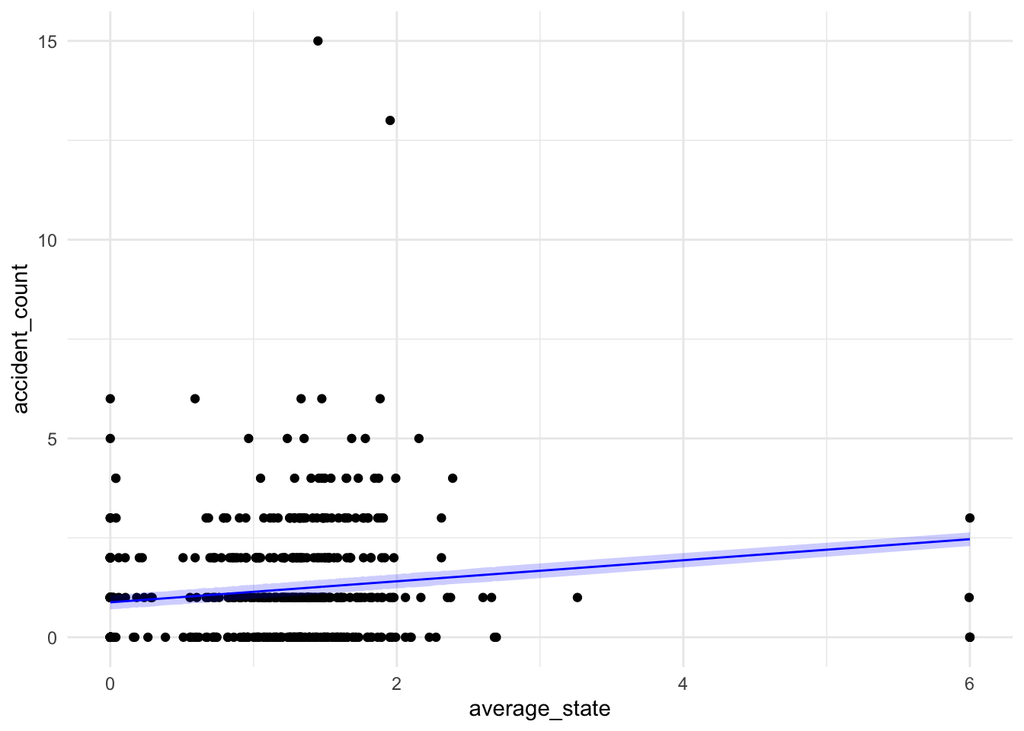

```r
# Create the plot
ggplot(fitted_values, aes(x = average_state, y = accident_count)) +
  geom_point() + # Plot the data points using the fitted_values dataframe
  geom_line(aes(y = fitted), color = "blue") + # Add the regression line
  geom_ribbon(aes(ymin = lower, ymax = upper), alpha = 0.2, fill = "blue") +
  theme_minimal() # A minimal theme for a cleaner look
```

Based on the model and chart presented above, we can say that in Barcelona, at the 1% significance level there exists evidence that increased traffic levels are associated with a higher number of accidents. Specifically, for every unit increase in the average state of a given street, there is, on average, a corresponding rise of 0.26 accidents, holding all other factors constant. We did the computation with robust standard erros to ensure homoscedasticity.

# 6. Regression Analysis: Predicting Victim Numbers

Having identified factors that correlate with accidents when considered individually, we now shift our focus to the victims, integrating some of the data examined in the previous section.

In this section, we employ linear regression analysis to identify variables that may influence the number of victims involved in car accidents. By considering factors explored in the previous sections as predictor variables, we aim to discern patterns and relationships that can inform strategies for mitigating accident severity and reducing human casualties.

```r
# Summarize the data by each 'Tram' (street segment)
accidents_count_per_tram <- accidents_with_streets %>%
  group_by(Tram, Nom_districte, Mes_any, Hora_dia) %>%
  summarise(victims_number = sum(Numero_victimes, na.rm = TRUE),
          accident_count = n(),
          avg_closest_distance = mean(closest_crosswalk_distance, na.rm = TRUE),
          .groups = 'drop')

# Convert 'accidents_count_per_tram' to a data frame if it's an sf object
accidents_count_per_tram_df <- as.data.frame(accidents_count_per_tram)

# Temporarily convert 'streets_within_city_limits' to a data frame if it's an sf object
streets_df <- as.data.frame(streets_within_city_limits)

# Perform the left join
accidents_count_per_street_df <- left_join(accidents_count_per_tram_df, streets_df , by = "Tram")

# Replace NA in accident_count with 0
#accidents_count_per_street_df$accident_count[is.na(accidents_count_per_street_df$accident_count)] <- 0

accidents_with_traffic_per_street <- accidents_count_per_street_df %>%
  left_join(traffic_january, by = c("Tram" = "idTram"))

# Run the linear regression
model <- lm(victims_number ~ Nom_districte + Hora_dia + avg_closest_distance + average_state, data = accidents_with_traffic_per_street)
summary(model)
```

```
##
## Call:
## lm(formula = victims_number ~ Nom_districte + Hora_dia + avg_closest_distance +
##     average_state, data = accidents_with_traffic_per_street)
##
## Residuals:
##     Min      1Q  Median      3Q     Max
## -1.6693 -0.3432 -0.2035  0.0246  8.6446
##
## Coefficients:
##                                    Estimate Std. Error t value Pr(>|t|)
## (Intercept)                       0.7986064  0.2424526   3.294  0.00105 **
## Nom_districteDesconegut          -0.4196663  0.4212213  -0.996  0.31952
## Nom_districteEixample             0.1465234  0.2203479   0.665  0.50634
## Nom_districteGràcia               0.0159509  0.2668792   0.060  0.95236
## Nom_districteHorta-Guinardó       0.1401383  0.2514483   0.557  0.57752
## Nom_districteLes Corts           -0.1741404  0.2534730  -0.687  0.49235
## Nom_districteNou Barris           0.0442079  0.2640765   0.167  0.86711
## Nom_districteSant Andreu          0.3706601  0.2568330   1.443  0.14952
## Nom_districteSant Martí           0.0291059  0.2434629   0.120  0.90488
## Nom_districteSants-Montjuïc       0.2072783  0.2431988   0.852  0.39441
## Nom_districteSarrià-Sant Gervasi  0.2181362  0.2388212   0.913  0.36143
## Hora_dia                          0.0175977  0.0075273   2.338  0.01974 *
## avg_closest_distance              0.0005346  0.0002430   2.200  0.02820 *
## average_state                     0.0415905  0.0560078   0.743  0.45804
## ---
## Signif. codes:  0 '***' 0.001 '**' 0.01 '*' 0.05 '.' 0.1 ' ' 1
##
## Residual standard error: 0.9485 on 569 degrees of freedom
## Multiple R-squared:  0.03829,    Adjusted R-squared:  0.01632
## F-statistic: 1.743 on 13 and 569 DF,  p-value: 0.04908
```

The linear regression model indicates that the total number of victims (Y) is influenced by several factors. Here’s a summary interpretation:

- Nom_districte (Districts): The coefficients for different districts indicate the change in the number of victims compared to a reference district. For instance, a coefficient of -0.17 for “Les Corts” district suggests that, on average, there are approximately -0.17 fewer victims in this district compared to the reference district when other variables are held constant. However, district coefficients are not statistically significant (p > 0.05), indicating that district alone might not be a strong predictor of the number of victims.
- Hora_dia (Hour of the day): The coefficient of 0.0176 suggests that for every one-unit increase in the hour of the day, there is an increase of approximately 0.018 victims, holding other variables constant. This coefficient is statistically significant (p = 0.01974), indicating that the time of day has a modest effect on the number of victims.
- avg_closest_distance: The coefficient of 0.0005346 suggests that for every one-unit increase in the distance to the closest crosswalks, there is an increase of approximately 0.000535 victims, holding other variables constant. This coefficient is statistically significant (p = 0.02820), indicating that higher distance from crosswalks might contribute to a slightly higher number of victims.
- average_state: The coefficient of 0.0416 suggests that for every one-unit increase in the traffic level, there is an increase of approximately 0.042 victims, holding other variables constant. However, this coefficient is not statistically significant (p = 0.45804), indicating that the average state might not be a significant predictor of the number of victims in this model.

Overall, the model has a low adjusted R-squared value of 0.01632, suggesting that the predictors included in the model explain only a small portion of the variance in the total number of victims. Further exploration and refinement of the model may be necessary to better understand the factors influencing the total number of victims in accidents.

# 7. Conclusions

Our exploration into Barcelona’s road safety has revealed some geospatial patterns that can foster furter research in order to shape effective policies. Delving into geospatial data, we identified both the spatial and temporal patterns that underscore car accidents in Barcelona, providing a foundation for developing targeted road safety strategies.

The distribution of accidents across the city, particularly spotlighting hotspots such as Eixample, and contrasting these with the severity of outcomes in different districts, underscores a nuanced landscape. Eixample, containing key transit routes like Avenida Diagonal and Gran Via de les Corts Catalanes, emerges as a primary locus of incidents. Yet, its high incident rate doesn’t necessarily correlate with the most severe outcomes. This complexity suggests that a multi-faceted approach, considering unique district characteristics from road design to traffic management, is crucial for addressing the spectrum of road safety challenges.

Our regression analysis further clarifies the factors influencing accident rates and the number of victims, highlighting intriguing correlations such as the negative relationship between accidents and the distance to crosswalks, and the positive association between traffic levels and accidents. These insights, while informative, also hint at the complexity of road safety dynamics, advocating for continued research and refined analytical models.

Lastly, our attempt at explaining the factors that impact victims revealed that the specific district has a minimal and statistically insignificant effect on the number of accident victims, suggesting that location alone may not strongly predict accident severity. Time of day was found to have a slight but statistically significant impact, indicating that accidents later in the day might slightly increase the number of victims. Distance from crosswalks also showed a significant but very small increase in victim numbers, pointing towards a marginal increase in risk with greater distance from pedestrian safety infrastructure. Traffic levels, however, did not significantly influence victim counts. Overall, the model suggests that these factors combined explain only a small fraction of the variation in the number of accident victims, highlighting the need for further investigation into other potential influences.

The findings highlight the intricate nature of improving urban safety, pointing to the essential role of cooperation among various sectors. By integrating the insights from geospatial analysis with efforts from government officials, urban developers, and community members, it’s possible to pinpoint areas at higher risk and create widespread enhancements in city safety. The literature review reveals numerous ways this approach can be applied, underscoring the importance of geospatial data in developing targeted and effective strategies for road safety. This method is pivotal for future research and policy development, with the aim of cultivating safer urban environments.

# Bibliography

Chaudhuri, S., Saez, M., Varga, D., & Juan, P. (2023). Spatiotemporal modeling of traffic risk mapping: A study of urban road networks in Barcelona, Spain. *Spatial Statistics, 53*, 100722. https://doi.org/10.1016/j.spasta.2022.100722

Haybat, H., Zerenoğlu, H., & Özlü, T. (2022). Temporal and spatial analysis of traffic accidents: the case of Bursa city. *International Journal of Geography and Geography Education (IGGE), 45*, 404-423. http://dx.doi.org/10.32003/igge.1016204

Lović Obradović, S., Rabiei-Dastjerdi, H., & Matović, S. (2022). Identifying spatiotemporal variability of traffic accident mortality: Evidence from the City of Belgrade, Serbia. *Central European Journal of Geography and Sustainable Development, 4(2), 78-93*. https://doi.org/10.47246/CEJGSD.2022.4.2.5

Mesquitela, J., Elvas, L. B., Ferreira, J. C., & Nunes, L. (2022). Data analytics process over road accidents data—A case study of Lisbon city. *ISPRS International Journal of Geo-Information, 11(2)*, 143. https://doi.org/10.3390/ijgi11020143

Shi, Y., Kilberry, M., Kharude, S., Biswas, R., Oram, J., Rao, D., Noori, M., Mays, J., & Chen, X. (2021). Predicting road accident risk using geospatial data and machine learning (Demo paper). In *SIGSPATIAL ’21: ACM SIGSPATIAL International Conference on Advances in Geographic Information Systems, November 02–05, 2021, Beijing, China*. ACM, New York, NY, USA, 4 pages. https://doi.org/10.1145/3474717.3484253